# Distance programing using AFCD data

The estimation in AFCD 2016-2017 used data from both AFCD and HKLR surveys. However, the appendix 1 and 2 only contained survey data by AFCD. Therefore, exact replication of abundance and density result is impossible given limited data.

The result is quite difference from that of AFCD.

## AFCD

WL(density, abundance): 96.49, 27 SWL(density, abundance): 12.94, 9 NWL(density, abundance): 11.53, 11

## Trial (limited data)

WL(density, abundance): 88.74, 29 SWL(density, abundance): 42.78, 28 NWL(density, abundance): 49.96, 44

The main differences lie on SWL and NWL. Honestly, I am not sure whether this due to data limitation or error in my method. I may need some time to figure out.

## Steps to use Distance

### Data preparation

I have done it in another programing language. Please refer to the other note

### Fitting models

Three models are used according to the methodology of AFCD. There are uniform, half-normal and hazard rate. Each of them, have three adjustment methods for model fitting. Therefore, there are total 9 trials for fitting models.

The model having the lowerest AIC was chosen, according to the methodology of AFCD.

Then, a detection function and QQplot are shown to visualize whether the model actually fits the data collected.

### Result extraction

By refering to the summary table, summary statistics are divided into cluster and individuals. What interest us is individuals.

There are lots of information in this summary table. I am not going to name it here.

## The following pages will show you how to use the Distance

# Data Import and Checking

```r
#import Distance
library("Distance")
```

```r
fiat <- read.csv("C:/Users/ustjo/Desktop/MM/dolphins/Data/fiat.csv")
```

```r
head(fiat)
```

| X | DATE | distance | size | Region.Label | Area | Sample.Label | Effort |
| --- | --- | --- | --- | --- | --- | --- | --- |
| 0 | 2016-04-06 | 0.058 | 12 | W LANTAU | 32.649 | 1 | 2.10 |
| 1 | 2016-04-14 | 0.074 | 4 | W LANTAU | 32.649 | 2 | 12.31 |
| 2 | 2016-04-22 | 0.132 | 1 | W LANTAU | 32.649 | 3 | 7.61 |
| 3 | 2016-04-22 | 0.063 | 2 | W LANTAU | 32.649 | 4 | 2.99 |
| 4 | 2016-04-22 | 0.196 | 1 | W LANTAU | 32.649 | 5 | 7.61 |
| 5 | 2016-04-26 | 0.294 | 1 | W LANTAU | 32.649 | 6 | 13.89 |

```r
#check data
#no error returned means good to go
check_data <- Distance:::checkdata(fiat)
```

# Model Fitting.

As explained in the introduction, it is expected to have 9 models and the model with lowest AIC will be chosen.

```r
#uniform model
fiat_uniform_cos <-ds(fiat, key = 'unif', adjustment = 'cos')
```

```
Starting AIC adjustment term selection.
Fitting uniform key function with cosine(1) adjustments
AIC= -94.662
Fitting uniform key function with cosine(1,2) adjustments


Error in model fitting, returning: uniform key function with cosine(1) adjustments

  Error: Error in setinitial.ds(ddfobj, width = meta.data$width, initial, point,  :
  Length of initial values for adjustments incorrect
```

```r
#uniform model
fiat_uniform_herm <-ds(fiat, key = 'unif', adjustment = 'herm')
```

```
Starting AIC adjustment term selection.
Fitting uniform key function with Hermite(4) adjustments
AIC= -63.862
Fitting uniform key function with Hermite(4,6) adjustments


Error in model fitting, returning: uniform key function with Hermite(4) adjustments

  Error: Error in setinitial.ds(ddfobj, width = meta.data$width, initial, point,  :
  Length of initial values for adjustments incorrect
```

```r
#uniform model
fiat_uniform_poly <-ds(fiat, key = 'unif', adjustment = 'poly')
```

```
Starting AIC adjustment term selection.
Fitting uniform key function with simple polynomial(2) adjustments
AIC= -43.721
Fitting uniform key function with simple polynomial(2,4) adjustments


Error in model fitting, returning: uniform key function with simple polynomial(2) adjustments

  Error: Error in setinitial.ds(ddfobj, width = meta.data$width, initial, point,  :
  Length of initial values for adjustments incorrect
```

```r
fiat_hn_cos <-ds(fiat, key = 'hn', adjustment = 'cos')
```

```
Starting AIC adjustment term selection.
Fitting half-normal key function
Key only model: not constraining for monotonicity.
AIC= -131.139
Fitting half-normal key function with cosine(2) adjustments
AIC= -158.566
Fitting half-normal key function with cosine(2,3) adjustments


Error in model fitting, returning: half-normal key function with cosine(2) adjustments

  Error: Error in setinitial.ds(ddfobj, width = meta.data$width, initial, point,  :
  Length of initial values for adjustments incorrect
```

```r
fiat_hn_herm <-ds(fiat, key = 'hn', adjustment = 'herm')
```

```
Starting AIC adjustment term selection.
Fitting half-normal key function
Key only model: not constraining for monotonicity.
AIC= -131.139
Fitting half-normal key function with Hermite(4) adjustments
AIC= -129.635

Half-normal key function selected.
```

```r
fiat_hn_poly <-ds(fiat, key = 'hn', adjustment = 'poly')
```

```
Starting AIC adjustment term selection.
Fitting half-normal key function
Key only model: not constraining for monotonicity.
AIC= -131.139
Fitting half-normal key function with simple polynomial(2) adjustments
AIC= -129.139

Half-normal key function selected.
```

```r
fiat_hr_cos <-ds(fiat, key = 'hr', adjustment = 'cos')
```

```
Starting AIC adjustment term selection.
Fitting hazard-rate key function
Key only model: not constraining for monotonicity.
AIC= -167.392
Fitting hazard-rate key function with cosine(2) adjustments
AIC= -165.488

Hazard-rate key function selected.
```

```r
fiat_hr_herm <-ds(fiat, key = 'hr', adjustment = 'herm')
```

```
Starting AIC adjustment term selection.
Fitting hazard-rate key function
Key only model: not constraining for monotonicity.
AIC= -167.392
Fitting hazard-rate key function with Hermite(4) adjustments
AIC= -165.392

Hazard-rate key function selected.
```

```r
fiat_hr_poly <-ds(fiat, key = 'hr', adjustment = 'poly')
```

```
Starting AIC adjustment term selection.
Fitting hazard-rate key function
Key only model: not constraining for monotonicity.
AIC= -167.392
Fitting hazard-rate key function with simple polynomial(2) adjustments
AIC= -165.392

Hazard-rate key function selected.
```

# Model Selection

Therefore, I just choose cosine adjustment.

Then, I plot the detection function and QQ plot check the fit.

It looks good!

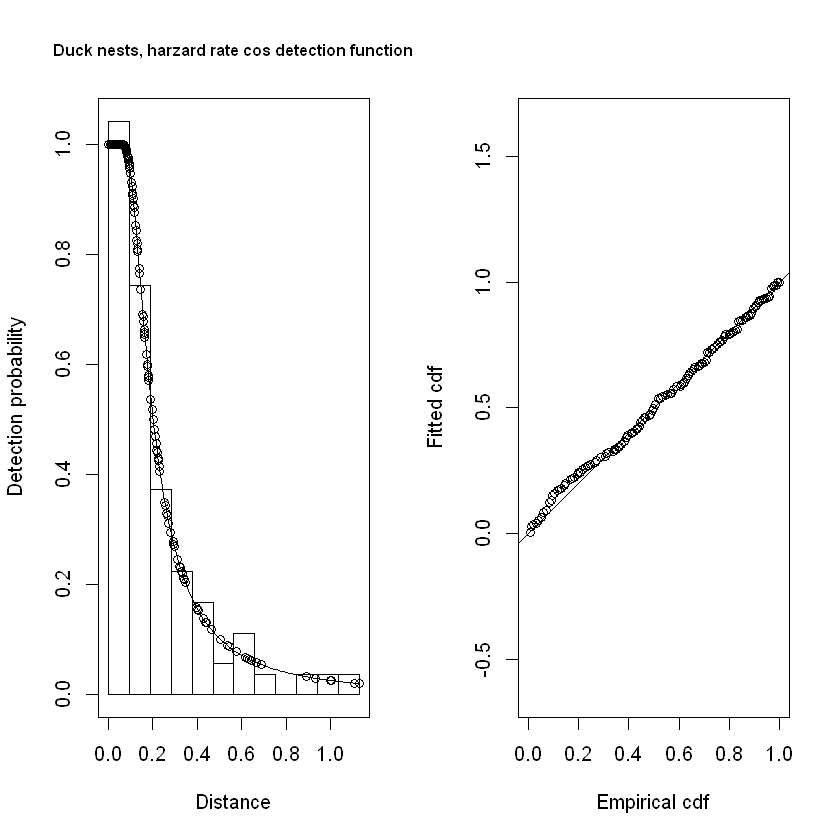

```r
#plot
par(mfrow=c(1,2)) #divide the figure windown to 1*2
plot(fiat_hr_cos, main="Duck nests, harzard rate cos detection function") #plot detection function
fit.test <- ddf.gof(fiat_hr_cos$ddf) #plot the QQ plot to fitness function
```

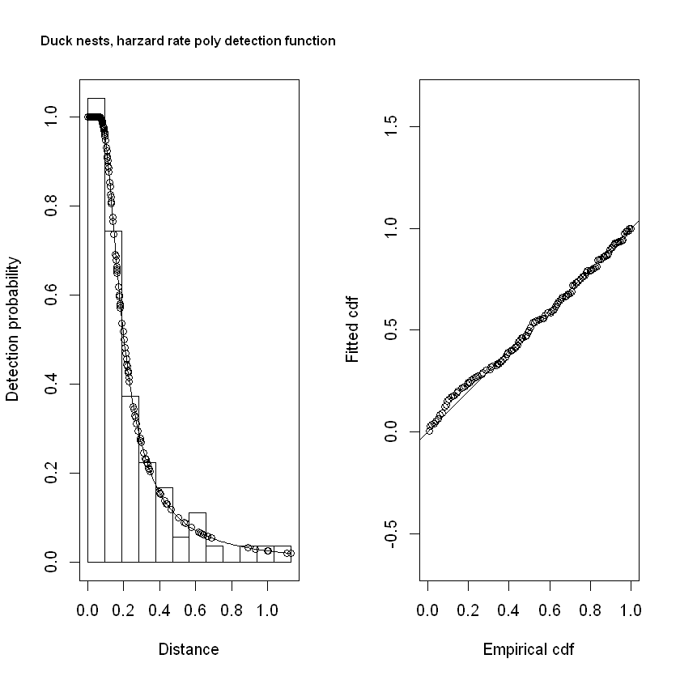

```r
#plot
par(mfrow=c(1,2)) #divide the figure windown to 1*2
plot(fiat_hr_poly, main="Duck nests, harzard rate poly detection function") #plot detection function
fit.test <- ddf.gof(fiat_hr_poly$ddf) #plot the QQ plot to fitness function
```

```r
#print out the summary statistics of hazard rate with cosine adjustment
summary(fiat_hr_cos)
```

```
Summary for distance analysis
Number of observations :  154
Distance range         :  0  -  1.129

Model : Hazard-rate key function
AIC   : -167.392

Detection function parameters
Scale coefficient(s):
             estimate       se
(Intercept) -1.784832 0.160718

Shape coefficient(s):
            estimate        se
(Intercept) 0.714291 0.1232653

                       Estimate          SE        CV
Average p             0.2387205  0.02533502 0.1061284
N in covered region 645.1059908 82.12532801 0.1273052

Summary for clusters

Summary statistics:
     Region    Area CoveredArea  Effort   n   k         ER       se.ER
1 NW LANTAU  87.415    410.8431  181.95  11  11 0.06045617 0.011976699
2 SW LANTAU  66.902    900.7614  398.92  37  37 0.09275043 0.011749036
3  W LANTAU  32.649   1822.1834  806.99 106 106 0.13135231 0.005427804
4     Total 186.966   3133.7879 1387.86 154 154 0.11096220 0.006063387
       cv.ER
1 0.19810548
2 0.12667366
3 0.04132248
4 0.05464372

Abundance:
      Label  Estimate       se        cv       lcl      ucl        df
1 NW LANTAU  9.804219 2.203421 0.2247421  6.130867 15.67849  16.47422
2 SW LANTAU 11.511752 1.902383 0.1652557  8.309744 15.94760  93.37913
3  W LANTAU  7.955986 0.906102 0.1138893  6.360045  9.95240 195.09008
4     Total 29.271957 3.956996 0.1351804 22.421837 38.21487 113.42020
```

[output cut: 27 more lines]

```
4     Total 101.26895 16.214292 0.1601112 73.56214 139.41140  49.44111

Density:
      Label  Estimate         se        cv       lcl       ucl        df
1 NW LANTAU 0.4996092 0.13293090 0.2660697 0.2852309 0.8751134  14.10881
2 SW LANTAU 0.4278469 0.09020884 0.2108437 0.2820215 0.6490746  62.86326
3  W LANTAU 0.8873717 0.12292989 0.1385326 0.6763804 1.1641799 256.97802
4     Total 0.5416437 0.08672321 0.1601112 0.3934520 0.7456511  49.44111

Expected cluster size
     Region Expected.S se.Expected.S cv.Expected.S
1 NW LANTAU   4.454545     0.9081814    0.20387745
2 SW LANTAU   2.486486     0.3627175    0.14587552
3  W LANTAU   3.641509     0.2837905    0.07793211
4     Total   3.459589     0.3413349    0.09866341
```

# Recap of the result

## AFCD

WL(density, abundance): 96.49, 27 SWL(density, abundance): 12.94, 9 NWL(density, abundance): 11.53, 11

## Trial (limited data)

WL(density, abundance): 88.74, 29 SWL(density, abundance): 42.78, 28 NWL(density, abundance): 49.96, 44

The main differences lie on SWL and NWL. Honestly, I am not sure whether this due to data limitation or error in my method.